# **Data for Pollock, White Hake, and Red Hake to be implemented in HYDRA**

# Growth Curves for Pollock, White Hake, and Red Hake

**Weight/Length**

The relationship between length and weight for these species as expressed by $W=a*L^b$

**Age/Length**

The von Bertalanffy growth curve was used to find the relationship between age and length using K and $L_{inf}$ as argument $L_{inf}*(1-exp(-k*t)$ for the following species.

## Pollock

The relationship between Pollock length (cm) and weight (lbs). The data was collected during NEFSC research bottom trawl surveys from 1992 to 1999. For the autumn surveys which were conducted from Cape Hatteras, North Carolina to Nova Scotia, Canada a= 0.000007244 and b= 3.1151 (Wigley et al., 2003). Winter/Spring surveys were conducted from Cape Hatteras, North Carolina to the Southern Flank of George’s Bank a= 0.000006788 and b= 3.1024.

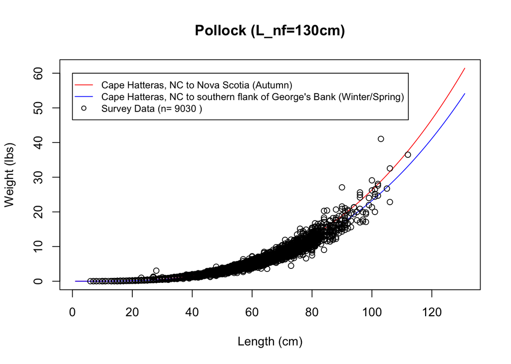

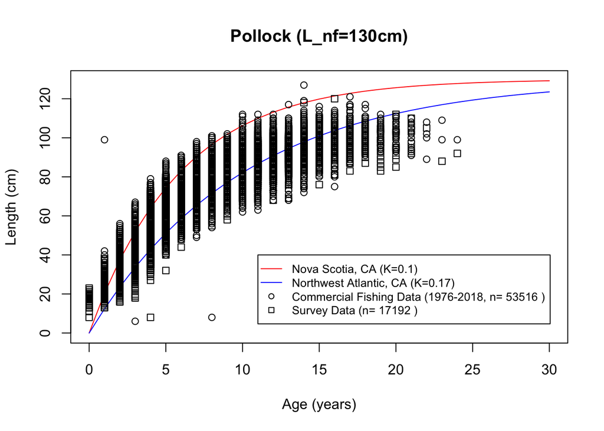

## Red Hake

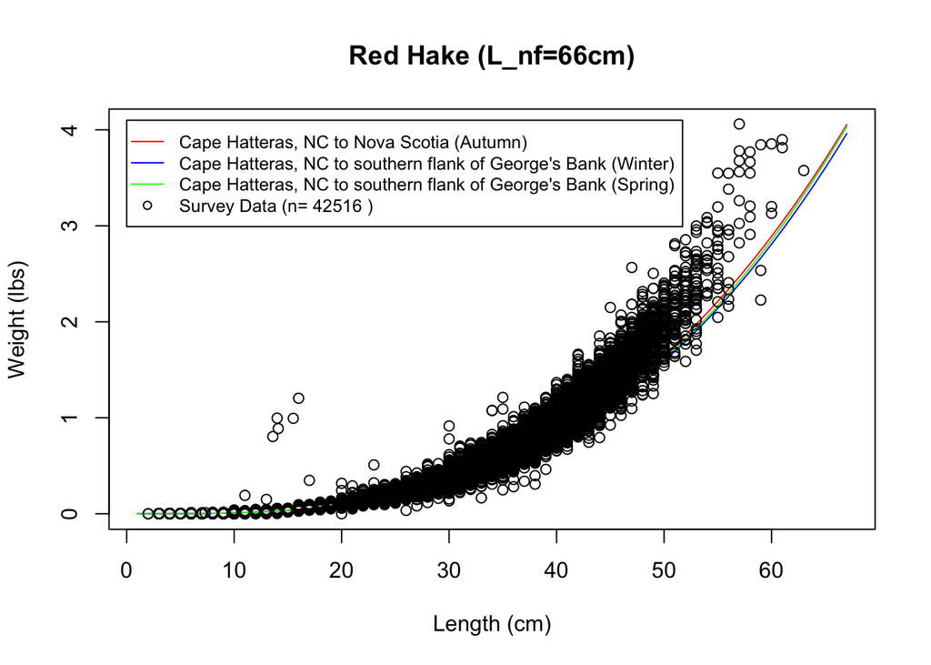

The relationship between red hake age (years) and length (cm) calculated by the von Bertalanffy growth rate for the North West Atlantic where K= 0.19 (Erzini, 1991). These growth rates are compared to survey data gathered by NEFSC.

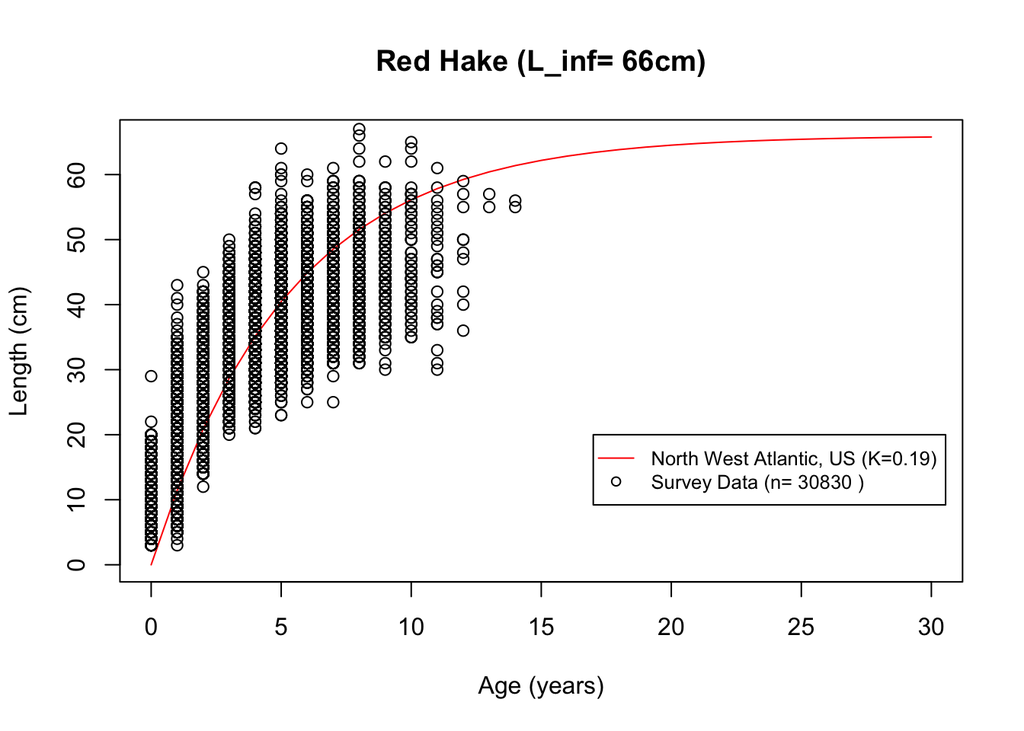

## White Hake

The relationship between white hake length (cm) and weight (lbs). The data was collected during NEFSC research bottom trawl surveys from 1992 to 1999. For the autumn surveys which were conducted from Cape Hatteras, North Carolina to Nova Scotia, Canada a= 0.000004119 and b=3.1715 (Wigley et al., 2003). Winter and spring surveys were conducted from Cape Hatteras, North Carolina to the Southern Flank of George’s Bank. For the winter surveys a= 0.000001904 and b= 3.3669. For the spring surveys a= 0.000002376 and b= 3.2903.

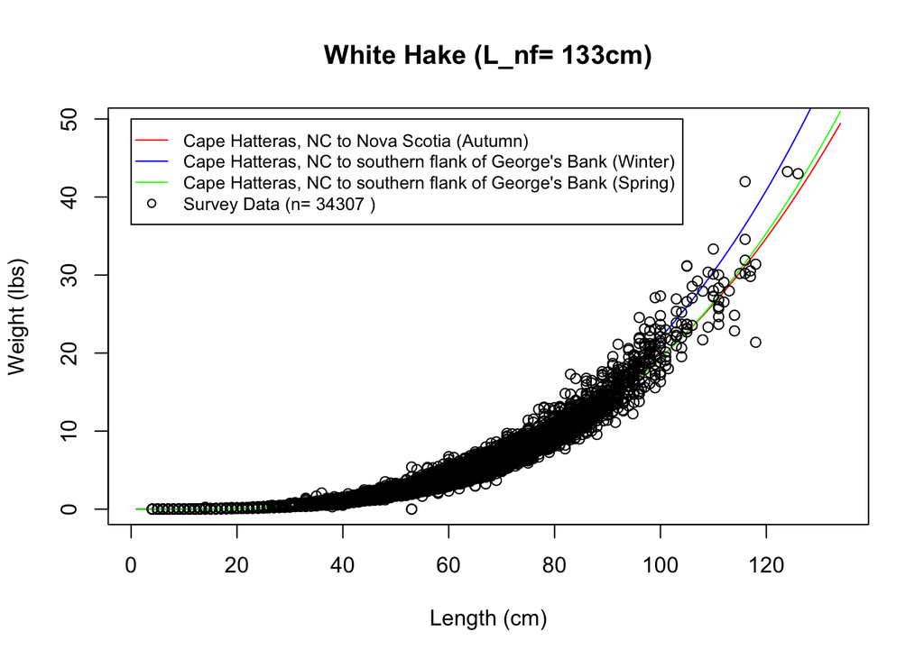

The relationship between white hake length and age calculated by the von Bertalanffy growth rate in two instances for the Southern Gulf of St. Lawrence in Canada where in one instance K= 0.218 and in the other K=0.106 (Clay D. & H. Clay, 1991). These growth rates are compared to survey data gathered by NEFSC.

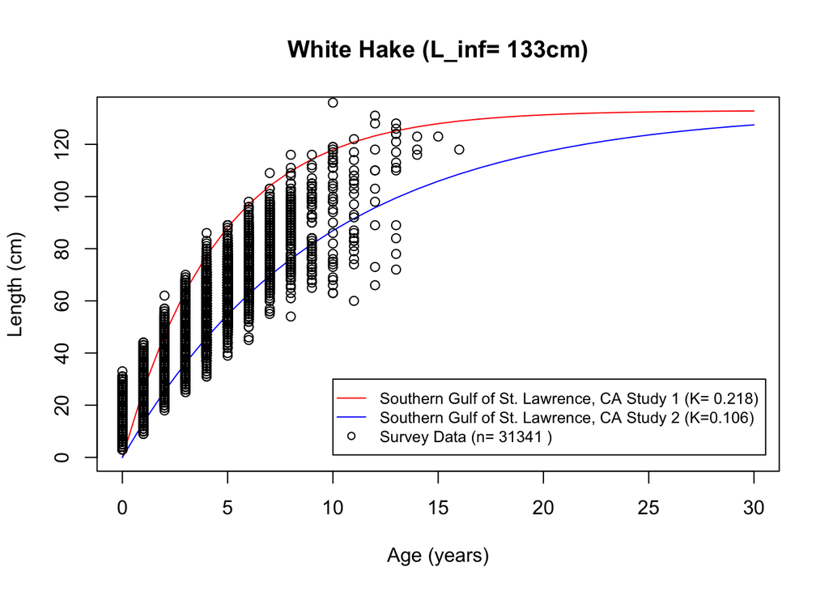

## Distribution of Lengths for Pollock, White Hake, and Red Hake

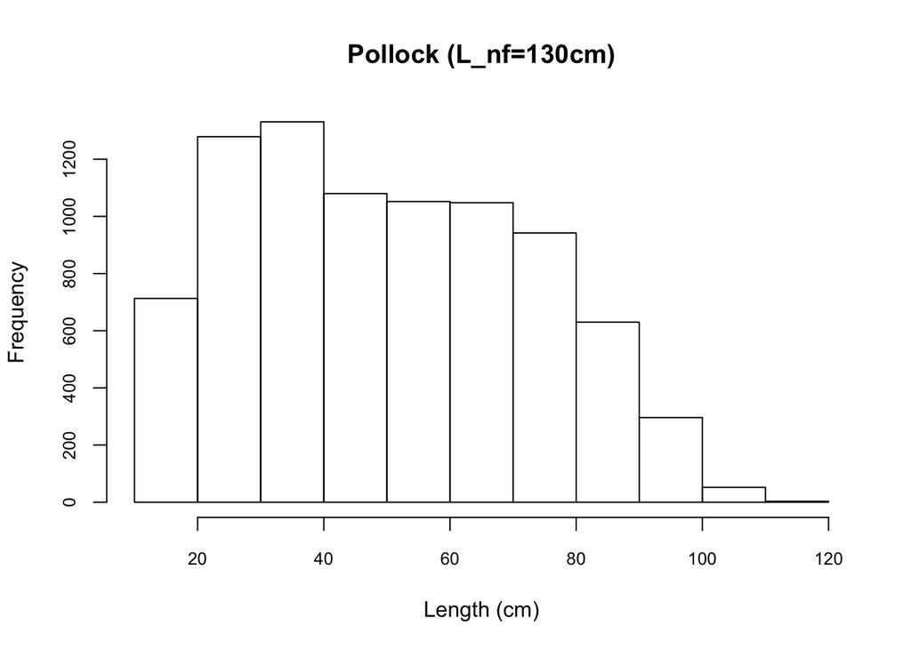

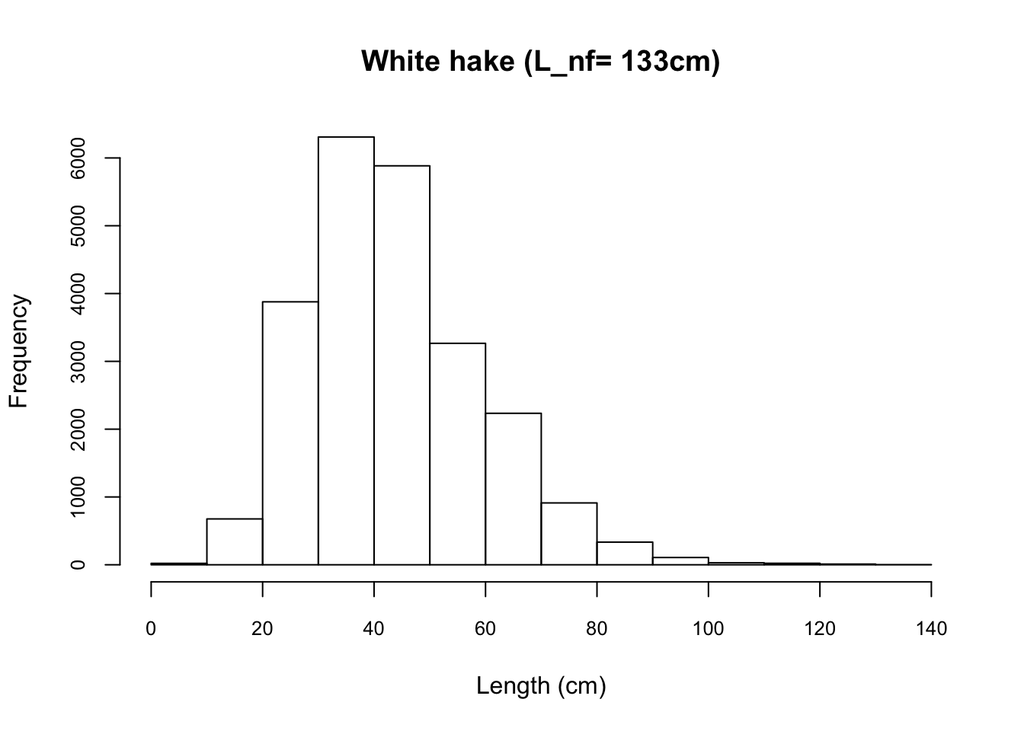

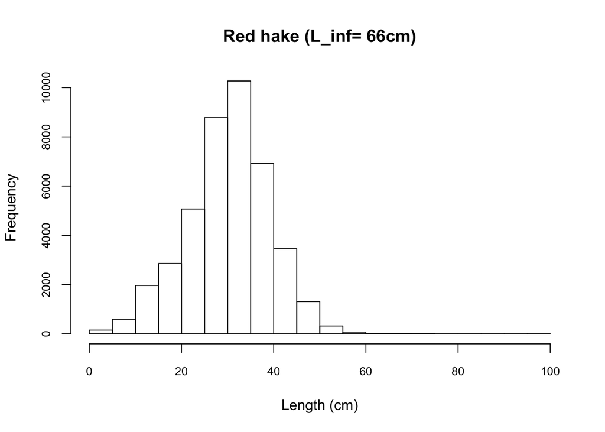

## Distribution of Mean Stomach Content Volume Across Varying Lengths

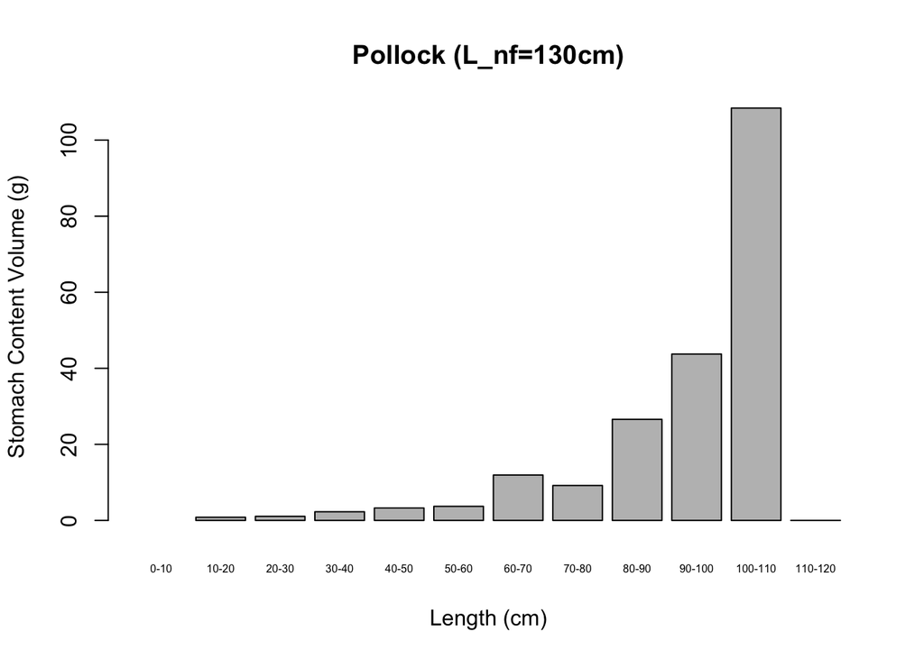

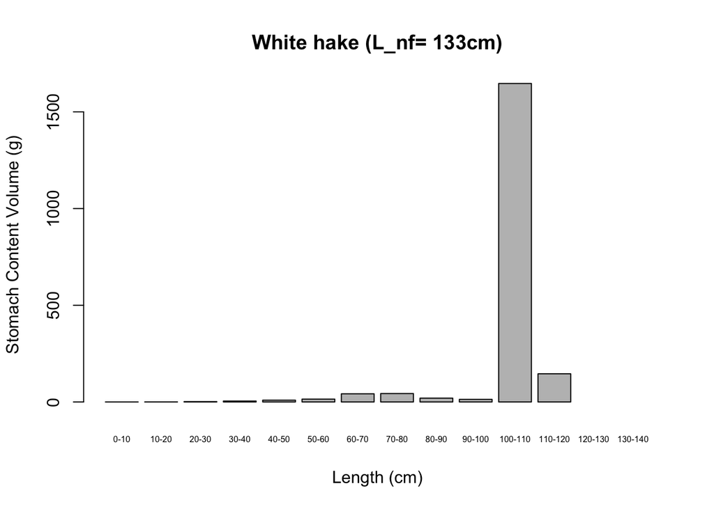

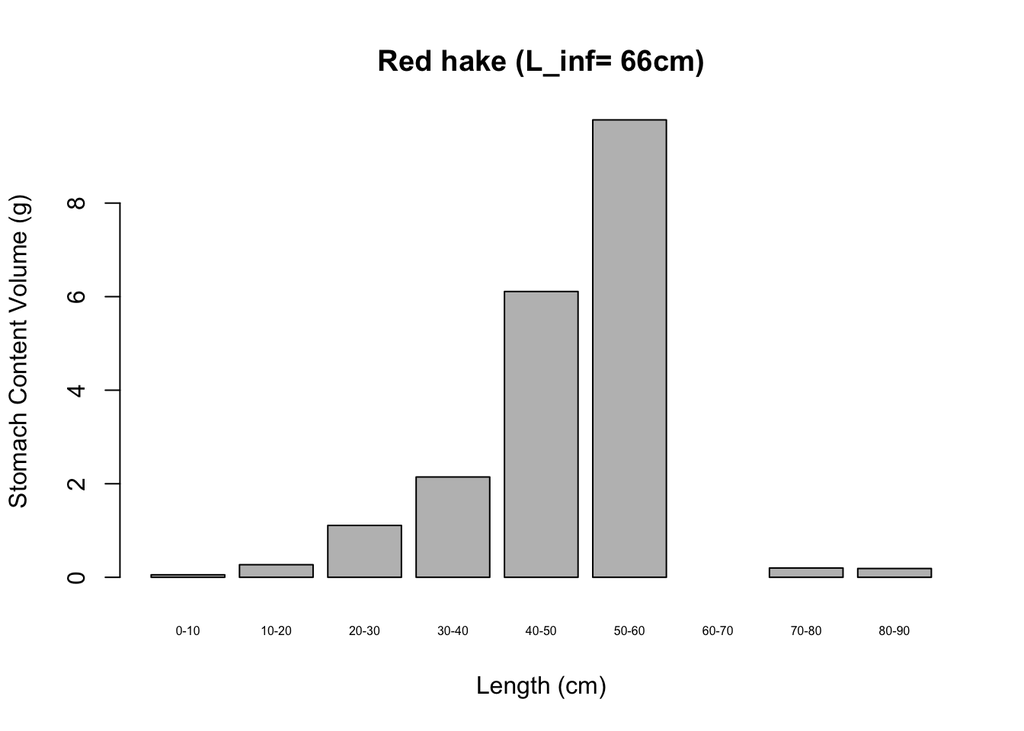